# COVID-19: A Midwestern Reporting Project of WNIN and the University of Evansville

Detroit ZIP Code Analysis

Analysis performed by Maya Frederick, Timmy Miller, Ethan Morlock, Pearl Muensterman, and Darrin Weber, Ph.D.

## Background

The goal of this analysis is to find any connections, if they exist, between demographic data and the outbreak of COVID-19 in the city of Detroit. Demographic data was obtained from the Census Bureau through their 5-year American Community Survey published in 2018 (the most recent 5-year data available). COVID-19 case numbers were obtained from the Detroit Department of Health. This data was pulled on October 8, 2020 from these resources. (https://codtableau.detroitmi.gov/t/DHD/views/CityofDetroit-PublicCOVIDDashboard/ZIPCodeCaseRatesDashboard?%3AisGuestRedirectFromVizportal=y&%3Aembed=y).

## Summary

To start we filtered out the zip codes 48233, 48242, and 48243. We filtered these out because they had no data included with case or death rate, which is likely due to an extremely small population or a non-population zip code. None of our demographics showed significant $p$-values when testing for correlations between the demographics and case rate. This seems odd; however, populations across Detroit are all relatively equally impacted by COVID-19. We also looked at the correlation between death rate and the demographics: occupations, citizenship, income, and race. None of these were significant either. Again, it appears as though the impact of COVID is equally distributed across the city of Detroit.

## Analysis

### COVID

[interactive chart not shown]

We see that COVID case rate is spread throughout Detroit, however ZIPs 48211, 48235, and 48207 do stand out as having a higher case rates.

[interactive chart not shown]

Here, we see that ZIP code 48207 has a high death rate.

### Occupations (Essential VS. Nonessential)

Many “essential” workers tend to be towards the lower end of the income bracket. We look at whether there is a relationship between essential workers and contracting COVID.

The Census Bureau breaks workers into five categories: Management, business, science and arts; service; sales and office; natural resources, construction, and maintenance; and production, transportation, and material moving. Although these categories are undoubtedly not clear distinctions between essential and non-essential, we feel a good classification is to put natural resources, construction, and maintenance and production, transportation, material moving as essential and the other three categories as non-essential.

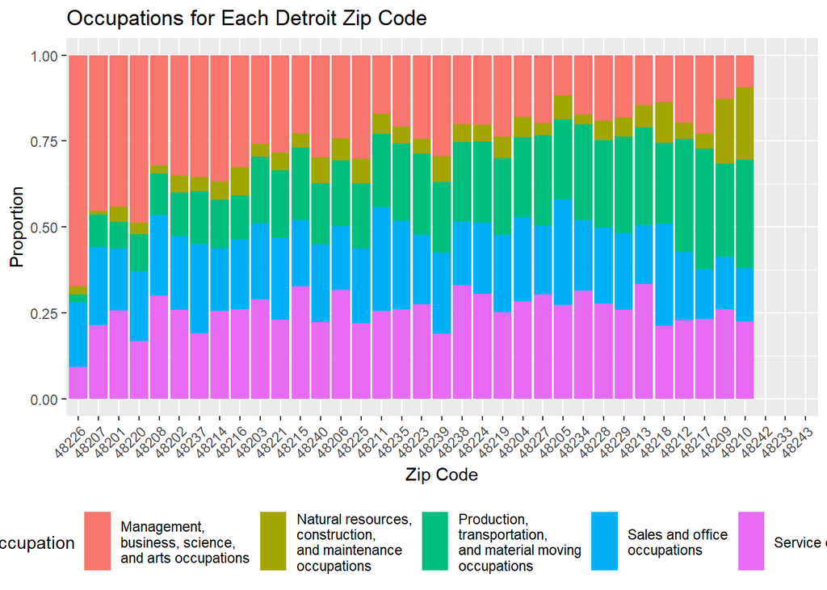

The scatterplot shows the correlation between essential jobs and COVID cases.

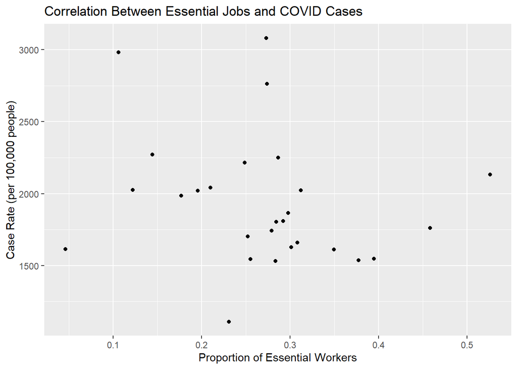

When we test our correlation to cases, we get a value of -0.210357 ($p=$ 0.292265). With such a high $p$-value, we cannot make any claim of a relationship between proportion of essential workers and COVID.

The scatterplot shows the correlation between essential jobs and COVID deaths.

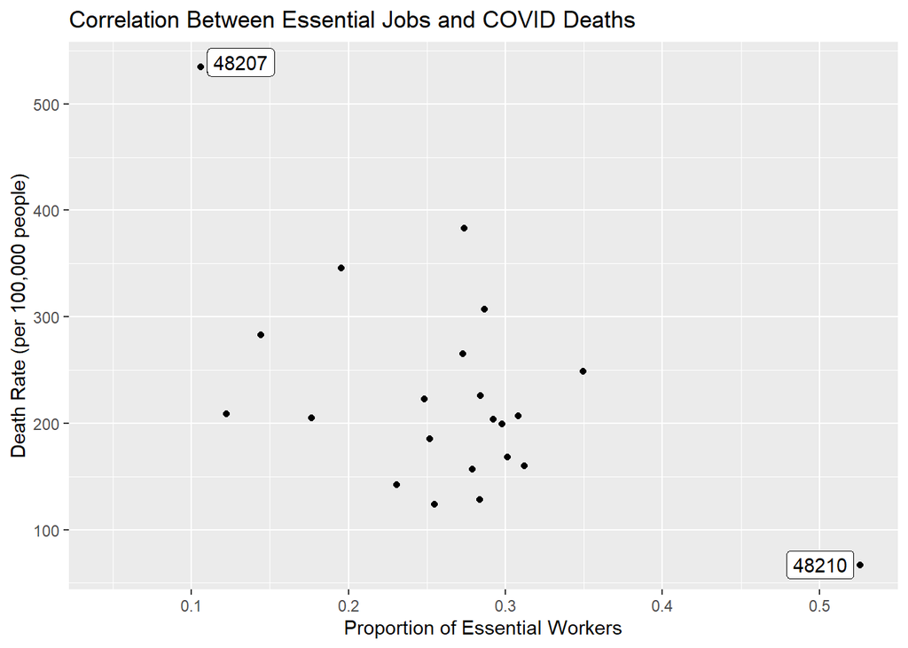

We notice two outliers, and thus must remove them. When we test our correlation on the remaining data, we get a value of -0.160072 ($p=$ 0.500223). Again, we see no significance here between death rate and proportion of essential workers.

### Citizenship

The Census Bureau provides a distinction between different types of U.S. citizenship (e.g., naturalization, born in U.S., born abroad, etc.). We focus on the simple distinction between being a U.S. citizen and not.

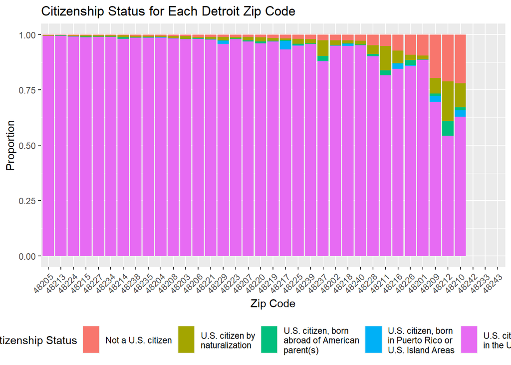

The scatterplot shows the correlation between not being a U.S. citizen and COVID cases in Detroit.

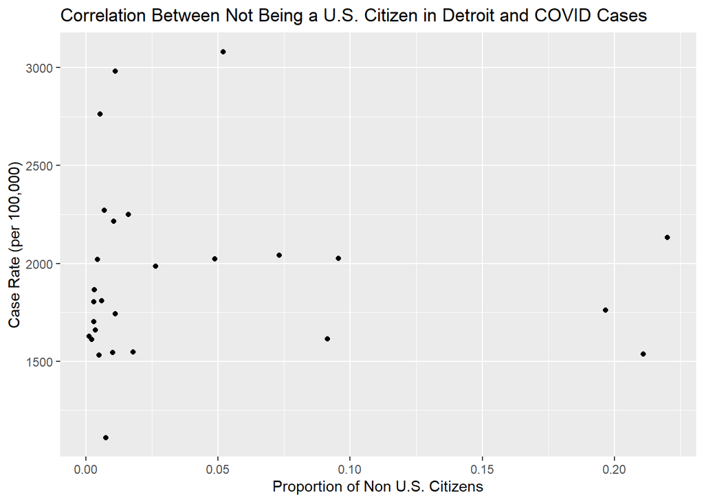

The scatterplot shows the correlation between not being a U.S. citizen and COVID deaths in Detroit.

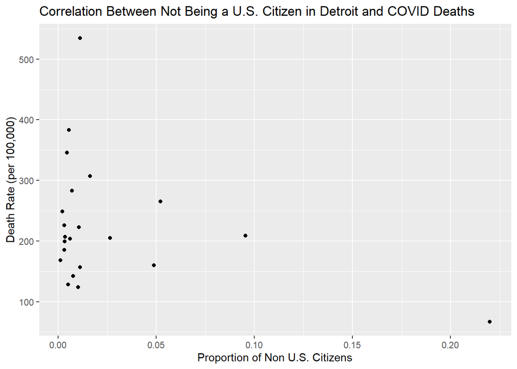

When we test our correlation, we get a value of -0.338432 ($p=$ 0.123415). This is a slight-to-moderate negative correlation, which means a ZIP code with a larger population of non-citizens is also showing a lower COVID death rate. However, the $p$-value is insignificant so we cannot make this assumption.

### Income

We look at the income data in increments designated by the Census Bureau. We calculated the proportion of people making over $100,000 to order the ZIP codes on the $x$-axis in the following graph.

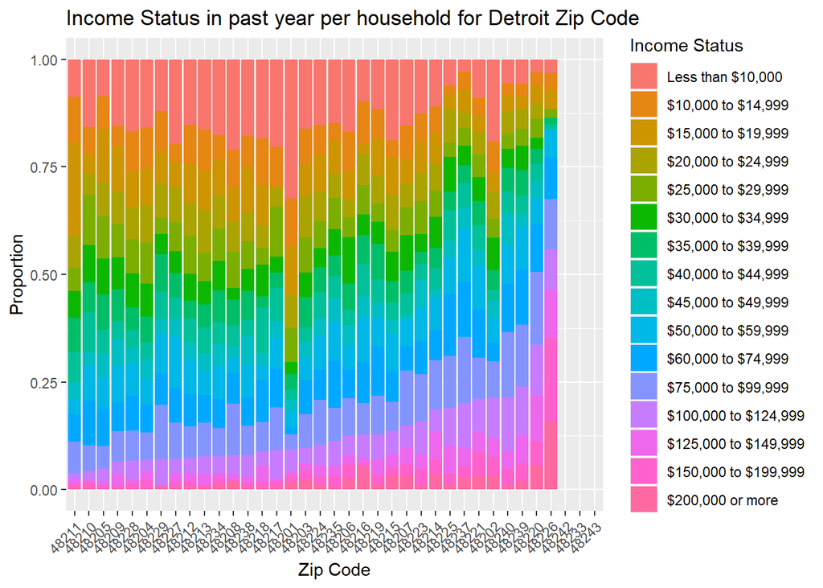

The scatterplot shows the correlation betweeen families making a six figure income or more in Detroit and COVID cases.

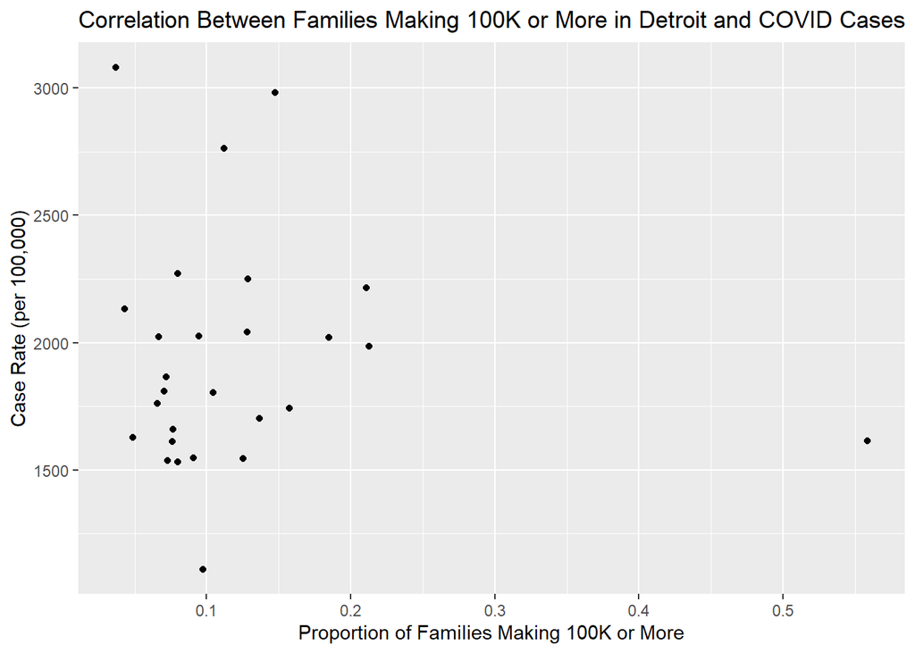

We see one outlier with a majority of the population making more than $100,000, however, it does not affect our correlation values by any great means. The correlation between a six-figure income and case rate is -0.077215 ($p\approx$ 0.701864). With this high of a $p$-value, we cannot establish any relationship between income and COVID.

The scatterplot shows the correlation between families making a six figure income or more in Detroit and COVID deaths.

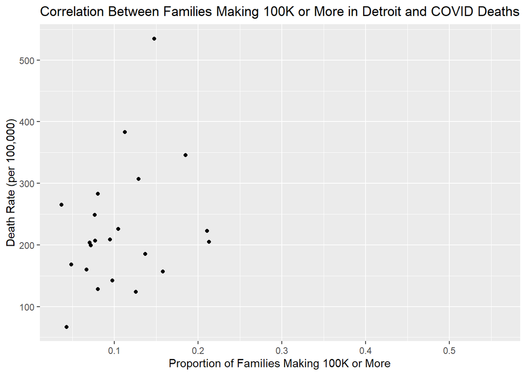

The correlation between a six-figure income and death rate is 0.302098 ($p\approx$ 0.171804). Again, our $p$-value is insignificant so we cannot determine any meaningful relationship.

### Race

We’ve heard reports about minorities being hit harder by COVID. We look to see if the data supports that in Detroit.

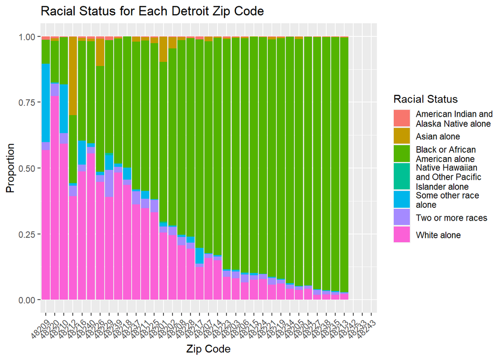

We mainly see two races that are inverses to each other: “white alone” and “Black or African American alone”. As the proportion of one race goes up, the other goes down. As a result, we’ll focus on the “Black or African American alone” population. The scatterplot shows the correlation between being an African American in Detroit and COVID cases.

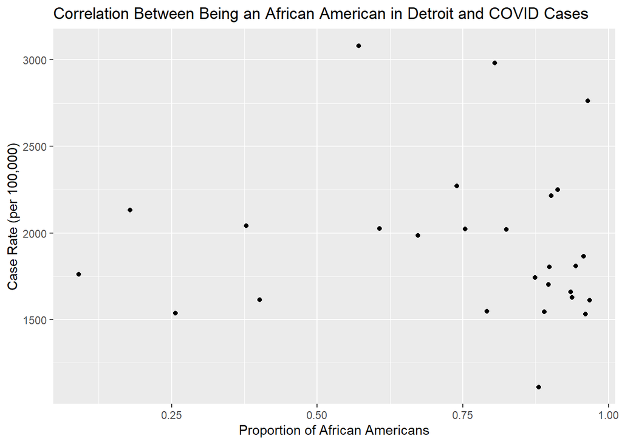

The correlation between the proportion of Black and African American within a ZIP code and case rate is -0.058171 ($p\approx$ 0.773187). Again, with a high $p$-value, we cannot make any conclusions that race is related to COVID cases.

This scatterplot shows the correlation between being an African American in Detroit and COVID deaths.

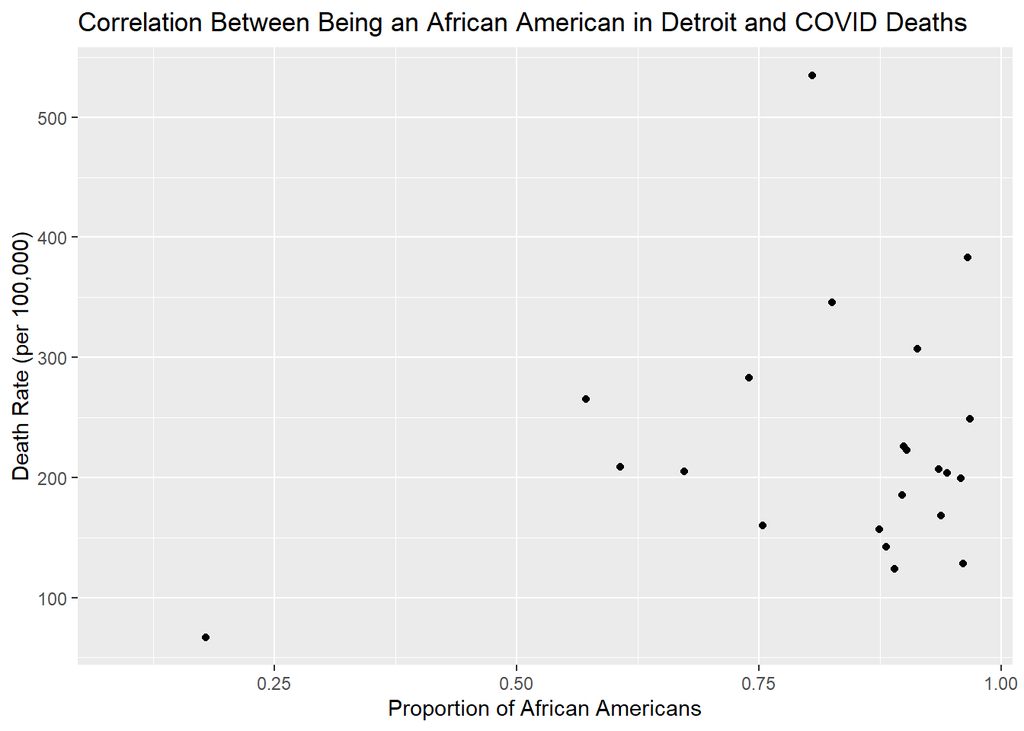

The correlation between the proportion of Black and African American within a ZIP code and death rate is 0.203156 ($p\approx$ 0.364527). Once again, our $p$-value is insignificant so we cannot make any conclusions.

### Gini Index

The scatterplot shows the correlation between Gini Index and COVID.

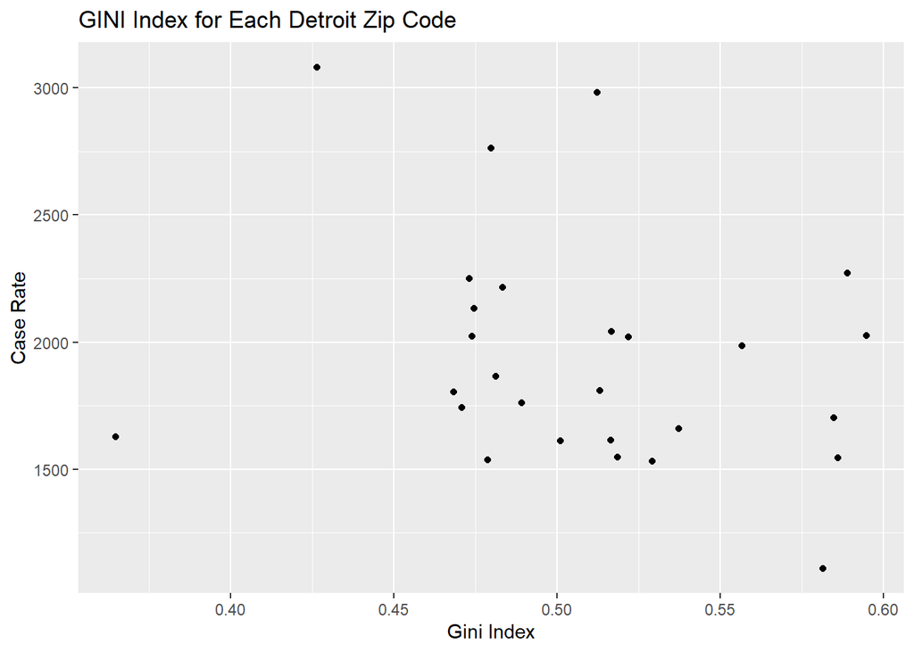

The correlation between GINI index and case rate is -0.254384, and the $p$-value is 0.200384, so we cannot conclude any significant relationship between these variables.

### Insurance Coverage(Public VS. Private)

We look at the proportion of people who have either private health insurance or public health insurance. It should be noted that having one type does not exclude you from having the other.

#### Private Health Insurance Coverage

We can observe the distribution of possession of private health insurance throughout the Detroit ZIP codes.

[figure not shown]

The plot below can give us a good indication as to the relationship between our two variables.

[figure not shown]

The correlation is 0.098759 and the $p$-value is 0.624074, so we cannot conclude any significant relationship between private health insurance coverage and case rate.

#### Public Health Insurance Coverage

We perform the same analysis with public health insurance coverage. First, we look at the distribution across the Detroit ZIP codes.

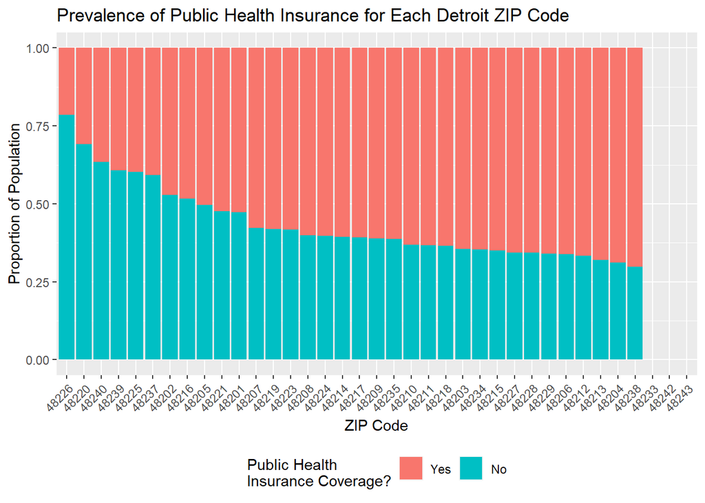

Looking at the scatterplot below, we see no real relationship exists.

[figure not shown]

This observation is borne out with our statistical tests. The correlation value is -0.051926 and the $p$-value is 0.797009, so we cannot conclude any relationship between public health insurance coverage and case rate.

### Transportation to Work

In this section, we consider the use of public transportation and whether it has any relationship to COVID.

First, we look at the distribution of different types of transportation across Detroit.

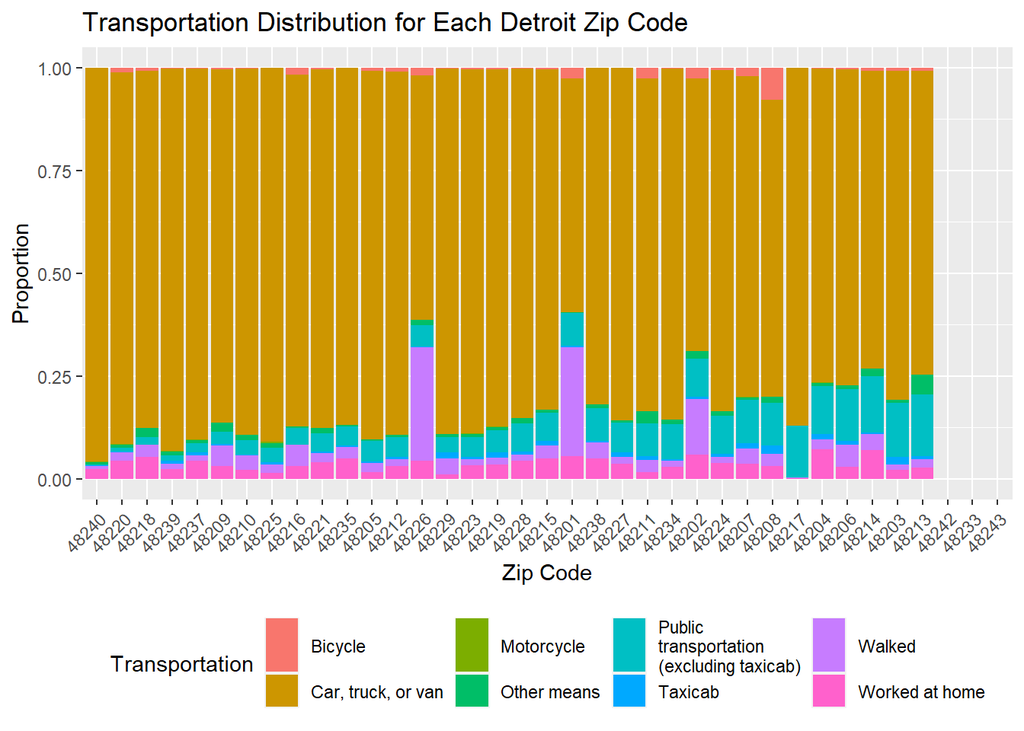

A large population take their own car, truck, or van. To further analyze this relationship, we group “Public Transportation (excluding taxicab)” and “Taxicab” together to create a public transportation use variable. The scatterplot shows the correlation between public transportation and COVID.

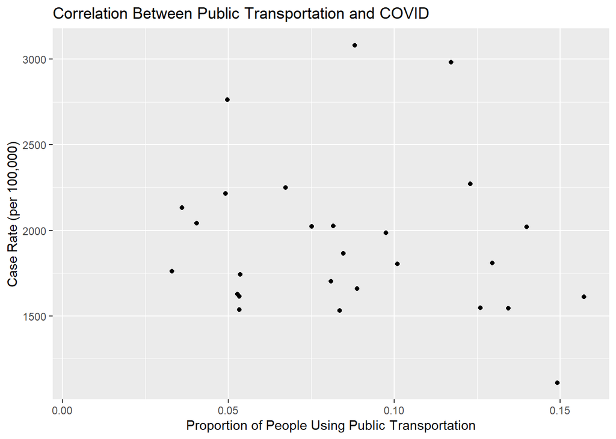

We see what looks like a slight negative relationship. However, our tests show us that the correlation between public transportation and case rate is -0.175669 with a $p$-value of 0.380784. This shows that we cannot conclude any significant relationship between these variables.

## Conclusions

In Detroit we looked at seven categories and analyzed eight variables within them by zip code. We removed ZIP codes 48233, 48242, and 48243 due to them having a tiny population or being a non-population zip code.

We did not have any significant correlations between our eight variables and case rate. We looked at the death rate for the variables occupations, citizenship, income, and race. These, too, did not show any significant relationship. This shows that Detroit may have an equal impact across all ZIP codes for COVID-19 or a more complicated relationship exists that we cannot detect with our current data.